# Homework #2

#### Computing ID: cx2rx

**SYS 6018 | Fall 2020 | University of Virginia**

### Problem 2.1: Bootstrapping

Bootstrap resampling can be used to quantify the uncertainty in a fitted curve.

1. Create a set of functions to generate data from the following distributions:
   $$\begin{align*}
   X &\sim \mathcal{U}(0, 2) \qquad \text{Uniform in $[0,2]$}\\
   Y &= 1 + 2x + 5\sin(5x) + \epsilon \\
   \epsilon &\sim \mathcal{N}(0,\, \sigma=2.5)
   \end{align*}$$

```r
# Build Distribution function for simulation
X <- function(n) {
  return(runif(n, min = 0, max = 2))
}
eps <- function(n) {
  return(rnorm(n, mean = 0, sd = 2.5))
}
Y <- function(x, err) {
  return(1 + 2 * x + 5 * sin(5 * x) + err)
}
```

2. Simulate $n=100$ realizations from these distributions. Produce a scatterplot and draw the true regression line $f(x) = E[Y \mid X=x]$. Use `set.seed(211)` prior to generating the data.

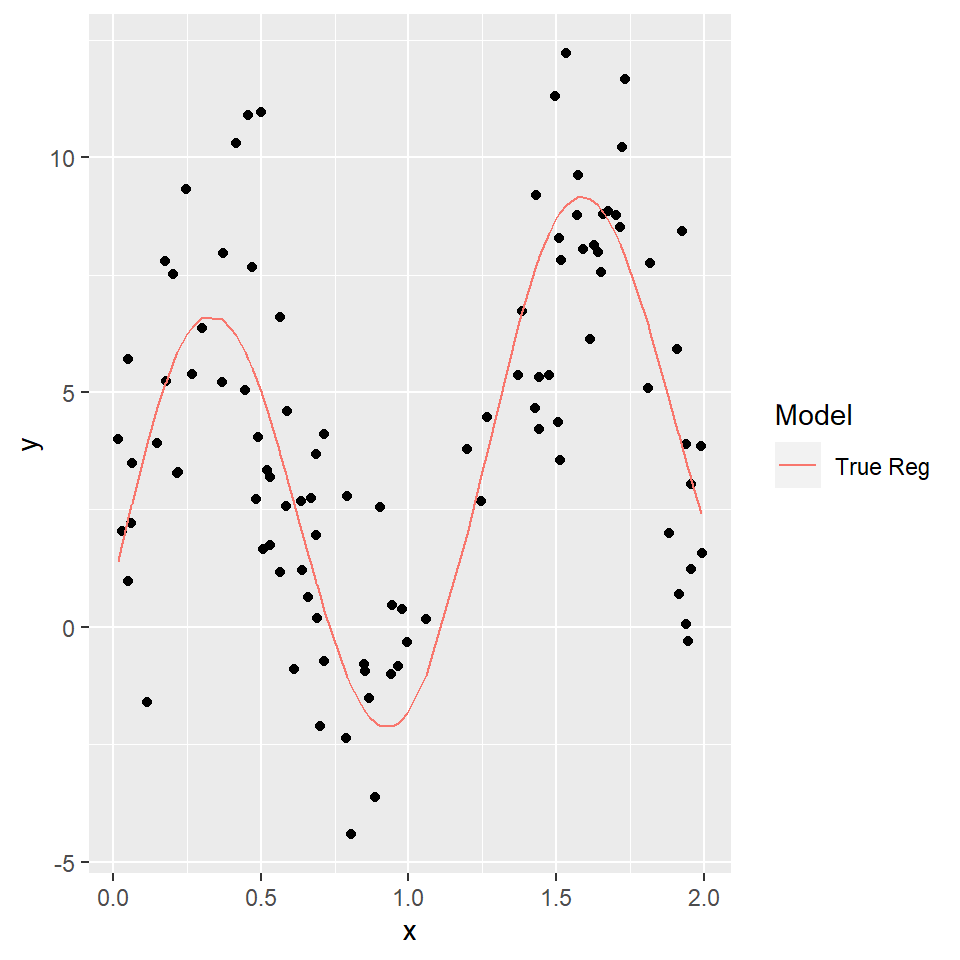

```r
# Randomness Control
set.seed(211)

# Pre-defined Parameters
n = 100

# Generate the realizations
x <- X(n)
err <- eps(n)
y <- Y(x = x, err = err)

# Build a data frame for graph
df <- data.frame(x, y)

# Create a scatter plot with the true regression line
ggplot(data = df) +
  geom_point(aes(x = x, y = y)) +
  geom_line(aes(x = x, y = Y(x, 0), color = "True Reg")) +
  scale_color_discrete(name = "Model")
```

3. Now fit a 5th degree polynomial. Produce a scatterplot and draw the *estimated* regression curve.

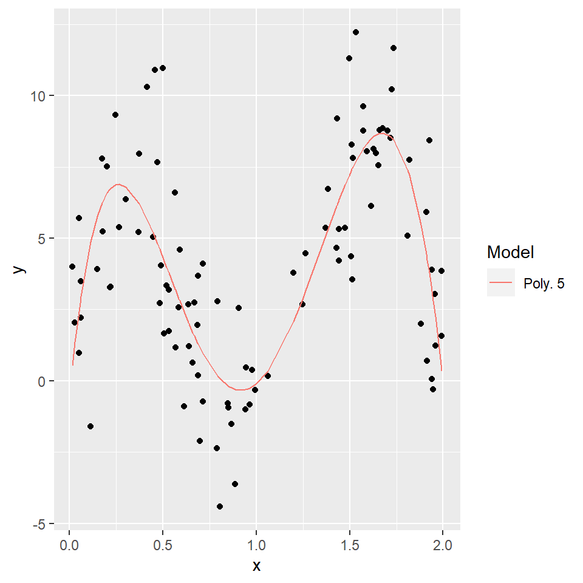

```r
# Build the 5th degree polynomial model
poly5 <- lm(y ~ poly(x, degree = 5), data = df)

# Merge prediction into df
df$poly5 <- poly5$fitted.values

# Scatter plot with estimated regression curve
ggplot(data = df) +
  geom_point(aes(x = x, y = y)) +
  geom_line(aes(x = x, y = poly5, color = "Poly. 5")) +
  scale_color_discrete(name = "Model")
```

4. Draw $200$ bootstrap samples, fit a 5th degree polynomial to each bootstrap sample, and make predictions at `eval.pts = seq(0, 2, length=100)`
   - Set the seed (use `set.seed(212)`) so your results are reproducible.
   - Produce a scatterplot and add the $200$ bootstrap curves

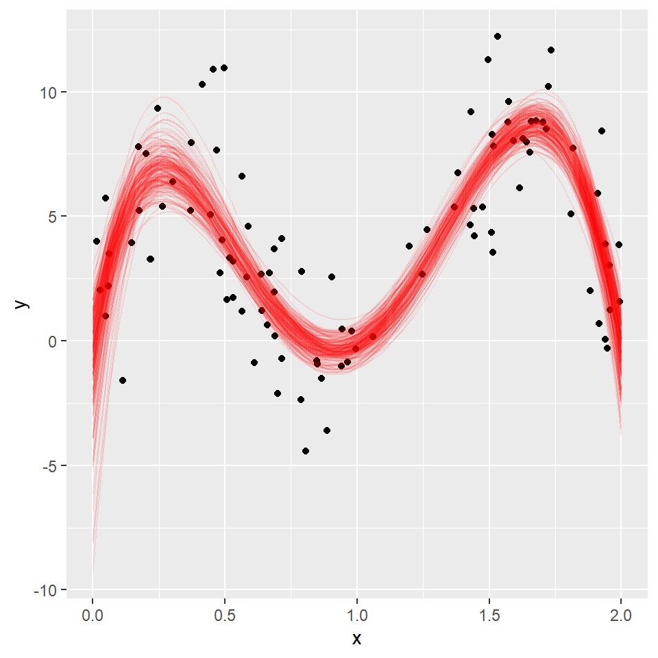

```r
# Randomness Control
set.seed(212)

# Pre-defined Parameters
M = 200
eval.pts <- data.frame(x = seq(0, 2, length=100))

# Create a list to store the bootstrap predictions
output <- list()

# Bootstrapping starts:
for(i in 1:M){

  # Sample with replacement
  ind <- sample(n, replace = TRUE)

  # Sampled Training Data
  data.boot <- df[ind,]

  # Fit regression model
  poly5_boot <- lm(y ~ poly(x, degree = 5), data = data.boot)

  # Store the prediction in output
  output[[i]] <- data.frame(Run = i,
                            x = eval.pts,
                            Fitted = poly5_boot$fitted.values,
                            Prediction = predict(poly5_boot, newdata = eval.pts))
}

# Convert list to data frame
output <- bind_rows(output)

# Scatter Plot with bootstrap predictions
ggplot(data = df) +
  geom_point(aes(x = x, y = y)) +
  # geom_line(aes(x = x, y = poly5, color = "Poly. 5")) +
  geom_line(data = output, color = "red", alpha = .10, aes(x = x, y = Prediction, group = Run)) +
  scale_color_discrete(name = "Model")
```

5. Calculate the pointwise 95% confidence intervals from the bootstrap samples. That is, for each $x \in {\rm eval.pts}$, calculate the upper and lower limits such that only 5% of the curves fall outside the interval at $x$.
   - Remake the plot from part *c*, but add the upper and lower boundaries from the 95% confidence intervals.

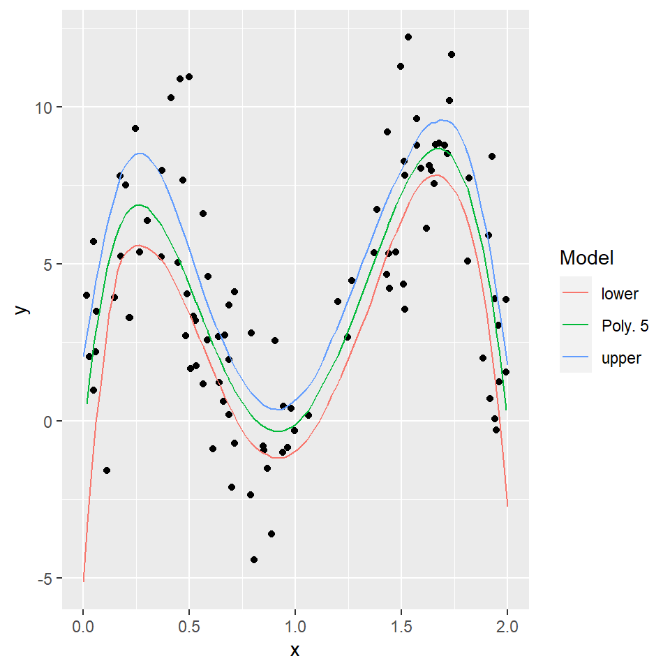

```r
CI <- output %>%
  group_by(x) %>%
  summarise(upper = quantile(Prediction, 0.975),
            lower = quantile(Prediction, 0.025))

ggplot(data = df) +
  geom_point(aes(x = x, y = y)) +
  geom_line(aes(x = x, y = poly5, color = "Poly. 5")) +
  geom_line(data = CI, aes(x = x, y = upper, color = "upper")) +
  geom_line(data = CI, aes(x = x, y = lower, color = "lower")) +
  scale_color_discrete(name = "Model")
```

### Problem 2.2: V-Fold cross-validation with $k$ nearest neighbors

Run 10-fold cross-validation on the data generated in part 1b to select the optimal $k$ in a k-nearest neighbor (kNN) model. Then evaluate how well cross-validation performed by evaluating the performance on a large test set. The steps below will guide you.

1. Use $10$-fold cross-validation to find the value of $k$ (i.e., neighborhood size) that provides the smallest cross-validated MSE using a kNN model. Search over $k=3,4,\ldots, 50$.
   - Use `set.seed(221)` prior to generating the folds to ensure the results are replicable.
   - Report the optimal $k$ (as determined by cross-validation), the corresponding estimated MSE, and produce a plot with $k$ on the x-axis and the estimated MSE on the y-axis (optional: add 1-standard error bars).

```r
# Randomness Control
set.seed(221)

# Pre-defined variables
K <- 3:50
n.folds <- 10
fold <- sample(rep(1:n.folds, length = nrow(df)))

# Create an empty output list
output <- list()

# Iterate over folds
for (k in K) {

  # Create an empty output list
  each_k <- list()

  for (i in 1:n.folds) {
    # Assign Train and Valid
    train <- df[which(fold != i),]
    valid <- df[which(fold == i),]

    # Fit KNN models
    model <- knn.reg(train = train[,'x', drop = FALSE],
                     y = train$y,
                     test = valid[,'x', drop = FALSE],
                     k = k)
    # Calculate the effective degrees of freedom
    edf <- nrow(train) / k

    # Calculate the MSE for validation data
    valid.mse <- mean((valid$y - model$pred)^2)

    # Create a data frame to store the results
    each_k[[i]] <- data.frame(valid.mse = valid.mse, edf = edf, k = k, fold = i)
  }
  # Store results to the larger list
  output[[k]] <- bind_rows(each_k)
}

# Convert list to data frame
output <- bind_rows(output)

# Report the Optimal k and Corresponding estimated MSE
output %>%
  group_by(k) %>%
  summarise(valid.mse = mean(valid.mse)) %>%
  filter(valid.mse == min(valid.mse))
```

```
#> # A tibble: 1 x 2
#>       k valid.mse
#>   <int>     <dbl>
#> 1     8      5.94
```

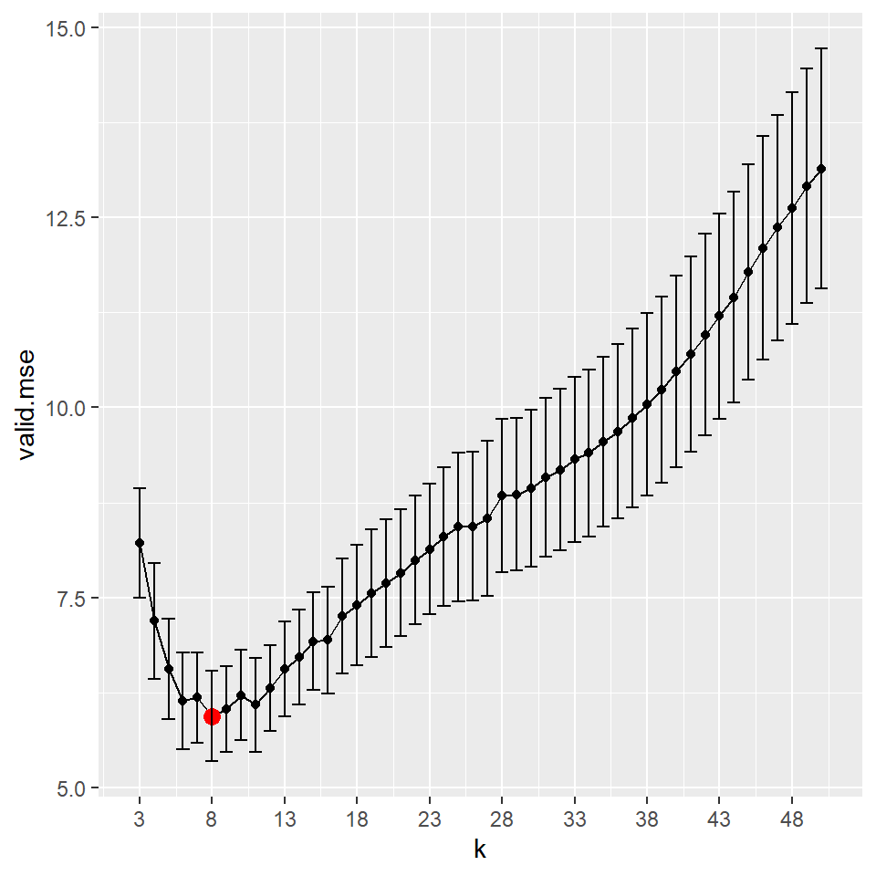

```r
# Create a plot of estimated MSE against k
output %>%
  group_by(k) %>%
  summarise(
    count = n(),
    valid.mse.se = sd(valid.mse) / sqrt(count),
    valid.mse = mean(valid.mse)
    ) %>%
  ggplot(aes(x = k, y = valid.mse)) +
  geom_point() +
  geom_line() +
  geom_point(data = . %>% filter(valid.mse == min(valid.mse)),
             color = "red",
             size = 3) +
  geom_errorbar(aes(ymin = valid.mse - valid.mse.se,
                    ymax = valid.mse + valid.mse.se)) +
  scale_x_continuous(breaks = seq(3, 50, 5))
```

2. The $k$ (number of neighbors) in a kNN model determines the effective degrees of freedom *edf*. What is the optimal *edf*? Be sure to use the correct sample size when making this calculation. Produce a plot similar to that from part *a*, but use *edf* (effective degrees of freedom) on the x-axis.

```r
# Optimal Effective Degree of Freedom
output %>%
  group_by(k) %>%
  summarise(valid.mse = mean(valid.mse)) %>%
  filter(valid.mse == min(valid.mse)) %>%
  left_join(output %>%
              select(k, edf) %>%
              unique.data.frame(), by = c('k'))
```

```
#> # A tibble: 1 x 3
#>       k valid.mse   edf
#>   <int>     <dbl> <dbl>
#> 1     8      5.94  11.2
```

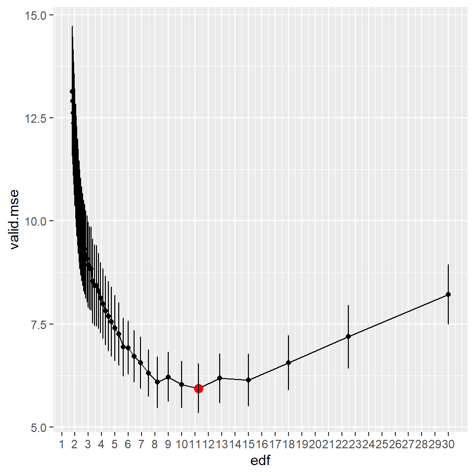

```r
# Create a plot of estimated MSE against edf
output %>%
  group_by(edf) %>%
  summarise(
    count = n(),
    valid.mse.se = sd(valid.mse) / sqrt(count),
    valid.mse = mean(valid.mse)
    ) %>%
  ggplot(aes(x = edf, y = valid.mse)) +
  geom_point() +
  geom_line() +
  geom_point(data = . %>% filter(valid.mse == min(valid.mse)),
             color = "red",
             size = 3) +
  geom_errorbar(aes(ymin = valid.mse - valid.mse.se,
                    ymax = valid.mse + valid.mse.se)) +
  scale_x_continuous(breaks = seq(1, 30, 1))
```

3. After running cross-validation, a final model fit from *all* of the training data needs to be produced to make predictions. What value of $k$ would you choose? Why?

I will choose $k = 8$ to fit all of the training data, because in part c, our cross-validation tells us that $k = 8$ gives us the best model with lowest Mean Squared Error for all $k \in \{3, 4, ..., 50\}$.

4. Now we will see how well cross-validation performed. Simulate a test data set of $50000$ observations from the same distributions. Use `set.seed(223)` prior to generating the test data.
   - Fit a set of kNN models, using the full training data, and calculate the mean squared error (MSE) on the test data for each model. Use the same $k$ values in *a*.
   - Report the optimal $k$, the corresponding *edf*, and MSE based on the test set.

```r
# Randomness Control
set.seed(223)

# Pre-defined Parameters
n = 50000

# Generate the realizations
x <- X(n)
err <- eps(n)
y <- Y(x = x, err = err)

# Create a data frame for test data
test <- data.frame(x = x, y = y)

# Fit a set of KNN Model:
# Create an empty output_test list
output_test <- list()

# Iterate over folds
for (k in K) {

  # Fit KNN models
  model <- knn.reg(train = df[,'x', drop = FALSE],
                   y = df$y,
                   test = test[,'x', drop = FALSE],
                   k = k)
  # Calculate the effective degrees of freedom
  edf <- nrow(df) / k

  # Calculate the MSE for validation data
  test.mse <- mean((test$y - model$pred)^2)

  # Create a data frame to store the results
  output_test[[k]] <- data.frame(test.mse = test.mse, edf = edf, k = k)

}

# Convert list to data frame
output_test <- bind_rows(output_test)

# Report the Optimal k and Corresponding estimated MSE
output_test %>%
  group_by(k) %>%
  summarise(test.mse = mean(test.mse)) %>%
  filter(test.mse == min(test.mse)) %>%
  left_join(output_test %>%
              select(k, edf) %>%
              unique.data.frame(), by = c('k'))
```

```
#> # A tibble: 1 x 3
#>       k test.mse   edf
#>   <int>    <dbl> <dbl>
#> 1    13     7.11  7.69
```

5. Plot both the cross-validation estimated and true test error on the same plot. See Figure 5.6 in ISL (pg 182) as a guide.
   - Produce two plots: one with $k$ on the x-axis and one with *edf* on the x-axis.

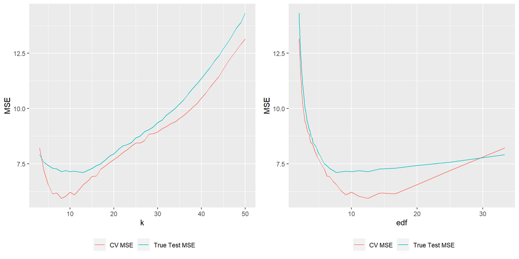

```r
df_plot <- output %>%
  group_by(k) %>%
  summarise(valid.mse = mean(valid.mse)) %>%
  right_join(output_test, by = c("k"))

p1 <- ggplot(data = df_plot) +
  geom_line(aes(x = k, y = valid.mse, color = "CV MSE")) +
  geom_line(aes(x = k, y = test.mse, color = "True Test MSE")) +
  theme(legend.position="bottom") +
  ylab("MSE") +
  scale_color_discrete(name = "")
p2 <- ggplot(data = df_plot) +
  geom_line(aes(x = edf, y = valid.mse, color = "CV MSE")) +
  geom_line(aes(x = edf, y = test.mse, color = "True Test MSE")) +
  theme(legend.position="bottom") +
  ylab("MSE") +
  scale_color_discrete(name = "")

grid.arrange(p1, p2, ncol = 2)
```

6. Based on the plots from *e*, does it appear that cross-validation worked as intended? How sensitive is the choice of $k$ on the resulting test MSE?

Based on the plots from Part e, we can see that our cross-validation curves have the correct general shape, but they underestimate the true test Mean Squared Error at almost all $k$. On the other hand, the CV curves come close to identifying the correct level of $k$. When $k \in [6, 13]$, the marginal change in MSE is relatively small for both CV curves and True Test MSE curves, so it is not sensitive to pick any $k$ values in this range. However, the choice of $k$ will be very sensitive in other ranges, as we can see that the slope of the CV Curves and True Test MSE curves is very steep.